# project-performance

Chongxi Wang

Apr 24, 2018

## Model Evaluation

### Part1 Salary Estimation

At first, let us see the result.

|  | Player | SalaryPred |
| --- | --- | --- |
| 7 | LaMarcus Aldridge | 25188212 |
| 17 | Carmelo Anthony | 25188212 |
| 31 | Harrison Barnes | 25188212 |
| 83 | Kentavious Caldwell-Pope | 25188212 |
| 112 | DeMarcus Cousins | 25188212 |
| 113 | Robert Covington | 25188212 |
| 120 | Stephen Curry | 25188212 |
| 122 | Anthony Davis | 25188212 |
| 140 | Andre Drummond | 25188212 |
| 143 | Kevin Durant | 25188212 |

[output cut: 530 more lines]

[figure not shown]

```r
source('..\\tests\\SalaryPredTest_rpart.R')
```

Then, let us see the real salaries.

```r
salary <- read.csv("..\\data\\PlayerSalary.csv", stringsAsFactors=F)
salary_1718 <- salary[, c("Player", "X1718")]
print(salary_1718)
```

| Player | X1718 |
| --- | --- |
| Stephen Curry | 34682550 |
| LeBron James | 33285709 |
| Paul Millsap | 31269231 |
| Gordon Hayward | 29727900 |
| Blake Griffin | 29512900 |
| Kyle Lowry | 28703704 |
| Russell Westbrook | 28530608 |
| Mike Conley | 28530608 |
| James Harden | 28299399 |
| DeMar DeRozan | 27739975 |

[output cut: 569 more lines]

In the result of tree model, generally speaking, good players earn high salaries and bad players earn low salaries. However, the prediction is not precise. Because of the limitation of classification, too many players earn the same, which is not the common situation.

As for the nodes, we can see the root node is to judge if MP < 30.05. It makes sense because 30 minutes is approximately the bound of stars and normal players. The next node is to judge if game number as starter < 49.5. It also makes sense because player that played 50 games as starter must be a qualified player. However, the next several nodes are all about age. I don’t think 23 years old and 24 years old make a big difference.

### Part2 Game Result Estimation

|  | Team | OppTeam | W | L |
| --- | --- | --- | --- | --- |
| 25 | ATL | BOS | 0.2967480 | 0.7032520 |
| 251 | ATL | BRK | 0.2967480 | 0.7032520 |
| 252 | ATL | CHI | 0.2967480 | 0.7032520 |
| 253 | ATL | CHO | 0.2967480 | 0.7032520 |
| 254 | ATL | CLE | 0.2967480 | 0.7032520 |
| 255 | ATL | DAL | 0.2967480 | 0.7032520 |
| 256 | ATL | DEN | 0.2967480 | 0.7032520 |
| 257 | ATL | DET | 0.2967480 | 0.7032520 |
| 258 | ATL | GSW | 0.2967480 | 0.7032520 |
| 259 | ATL | HOU | 0.2967480 | 0.7032520 |

[output cut: 860 more lines]

[figure not shown]

```r
source('..\\tests\\GamePredTest_rpart.R')
```

Then, let us see the real game result.

```r
team_list <- read.csv("..\\data\\TeamList.csv", stringsAsFactors=F)
game_data = data.frame()
for (i in 1:30) {
    team_id <- team_list[,1][i]
    team_log <- read.csv(paste("..\\data\\TeamGameLog1718\\", team_id, ".csv", sep=""), stringsAsFactors=F)
    team_col = rep(team_id, 82)
    team_log <- data.frame(Team=team_col, team_log)
    game_data <- rbind(game_data, team_log)
}
print(game_data)
```

| Team | Rk | G | Date | X | Opp | W.L | Tm | Opp.1 | FG | FGA | FG. | X3P | X3PA | X3P. | FT | FTA | FT. | ORB | TRB | AST | STL | BLK | TOV | PF | X.1 | FG.1 | FGA.1 | FG..1 | X3P.1 | … |
| --- | --- | --- | --- | --- | --- | --- | --- | --- | --- | --- | --- | --- | --- | --- | --- | --- | --- | --- | --- | --- | --- | --- | --- | --- | --- | --- | --- | --- | --- | --- |
| ATL | 1 | 1 | 2017-10-18 | @ | DAL | W | 117 | 111 | 48 | 94 | 0.511 | 9 | 18 | 0.500 | 12 | 15 | 0.800 | 14 | 50 | 20 | 11 | 6 | 13 | 18 | NA | 38 | 86 | 0.442 | 17 | … |
| ATL | 2 | 2 | 2017-10-20 | @ | CHO | L | 91 | 109 | 36 | 95 | 0.379 | 7 | 30 | 0.233 | 12 | 14 | 0.857 | 6 | 38 | 19 | 11 | 4 | 13 | 29 | NA | 37 | 86 | 0.430 | 11 | … |
| ATL | 3 | 3 | 2017-10-22 | @ | BRK | L | 104 | 116 | 32 | 94 | 0.340 | 7 | 27 | 0.259 | 33 | 36 | 0.917 | 16 | 48 | 21 | 6 | 2 | 16 | 25 | NA | 41 | 87 | 0.471 | 11 | … |
| ATL | 4 | 4 | 2017-10-23 | @ | MIA | L | 93 | 104 | 36 | 76 | 0.474 | 7 | 17 | 0.412 | 14 | 18 | 0.778 | 6 | 41 | 14 | 9 | 1 | 20 | 17 | NA | 39 | 85 | 0.459 | 14 | … |
| ATL | 5 | 5 | 2017-10-26 | @ | CHI | L | 86 | 91 | 32 | 81 | 0.395 | 11 | 28 | 0.393 | 11 | 13 | 0.846 | 7 | 40 | 22 | 10 | 5 | 10 | 23 | NA | 31 | 86 | 0.360 | 7 | … |
| ATL | 6 | 6 | 2017-10-27 |  | DEN | L | 100 | 105 | 37 | 89 | 0.416 | 14 | 33 | 0.424 | 12 | 12 | 1.000 | 11 | 43 | 23 | 7 | 4 | 12 | 21 | NA | 42 | 91 | 0.462 | 4 | … |
| ATL | 7 | 7 | 2017-10-29 |  | MIL | L | 106 | 117 | 36 | 77 | 0.468 | 13 | 29 | 0.448 | 21 | 26 | 0.808 | 3 | 31 | 27 | 9 | 2 | 16 | 21 | NA | 44 | 81 | 0.543 | 13 | … |
| ATL | 8 | 8 | 2017-11-01 | @ | PHI | L | 109 | 119 | 41 | 94 | 0.436 | 8 | 23 | 0.348 | 19 | 27 | 0.704 | 12 | 49 | 22 | 11 | 4 | 18 | 28 | NA | 46 | 99 | 0.465 | 13 | … |
| ATL | 9 | 9 | 2017-11-03 |  | HOU | L | 104 | 119 | 39 | 81 | 0.481 | 11 | 33 | 0.333 | 15 | 18 | 0.833 | 5 | 41 | 16 | 8 | 8 | 18 | 16 | NA | 42 | 89 | 0.472 | 16 | … |
| ATL | 10 | 10 | 2017-11-05 | @ | CLE | W | 117 | 115 | 41 | 86 | 0.477 | 11 | 25 | 0.440 | 24 | 34 | 0.706 | 11 | 44 | 24 | 4 | 6 | 17 | 20 | NA | 42 | 96 | 0.438 | 10 | … |

[output cut: 990 more lines]

### Part3 Team Quality Estimation

At first, let us see the result.

```r
source('..\\tests\\TeamQualityPredTest_rpart.R')
```

|  | Team | Quality |
| --- | --- | --- |
| 28 | TOR | 97.1 |
| 6 | CLE | 96.0 |
| 10 | GSW | 95.3 |
| 18 | MIN | 86.3 |
| 20 | NYK | 86.3 |
| 23 | PHI | 84.6 |
| 19 | NOP | 84.2 |
| 27 | SAS | 82.2 |
| 8 | DEN | 33.0 |
| 29 | UTA | 32.3 |

[output cut: 20 more lines]

Then, let us see the real NBA standings.

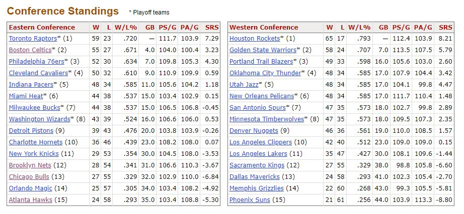

2017/18 NBA Conference Rankings

From the form, the prediction result is ok and the playoff teams are still ranking in the first 16 teams. The ranking is more accurate than linear model but improvement is still needed.

### Part4 Trading & Signing Proposal

todo..

## Project Evaluation

The most valuable part of this project is the Trading & Signing Proposal part, which is not done yet.

At present, the models are able to roughly predict the results. In the next step, I will list possible trading & signing choices and calculate each team quality after operation to find an optimal operation.

Those trades and signings in 2017-18 season can be used to evaluating this project.